# Lecture 9: Point Level Models - Model Fitting, cont..

# Class Intro

## Intro Questions

- Describe the process for finding the BLUP in this situation:

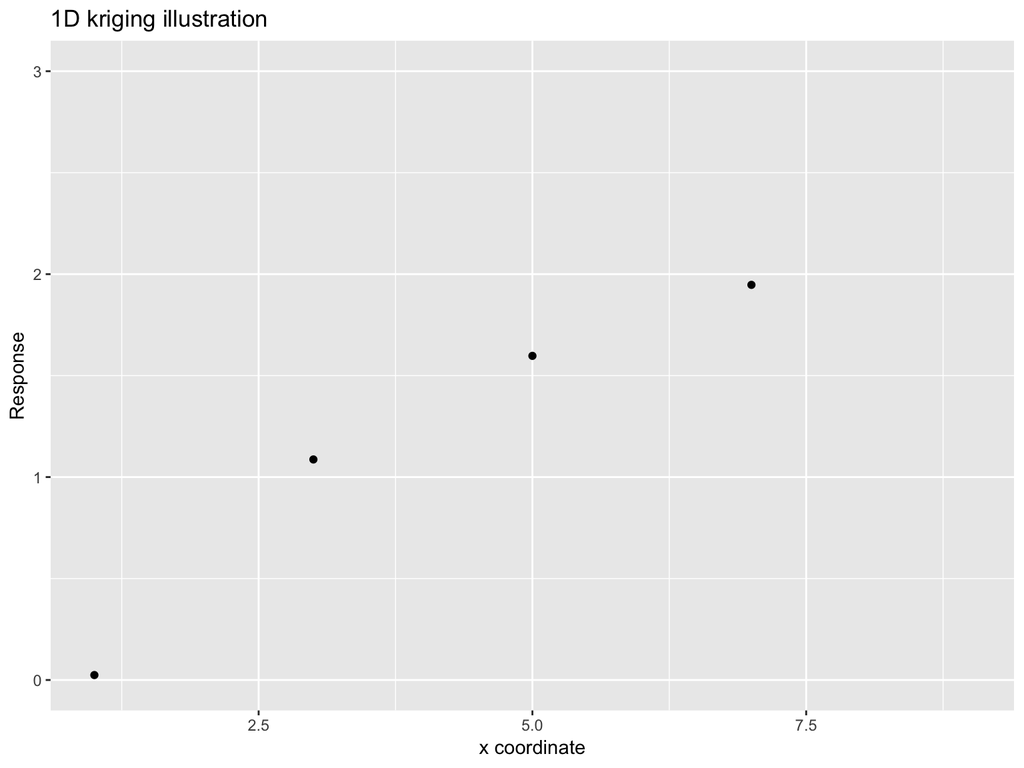

## Intro Questions

- For Today:
  - More Model Fitting

# Model Fitting

## BLUP

- It turns out that the solution for the vector $\boldsymbol{l}$ is
  $$\boldsymbol{l} = \Gamma^{-1} \left( \boldsymbol{\gamma_0} + \frac{(1 - \boldsymbol{1}^T \Gamma^{-1} \boldsymbol{\gamma_0})}{\boldsymbol{1}^T \Gamma^{-1} \boldsymbol{1}}\boldsymbol{1}\right),$$
  where $\Gamma$ is an $n \times n$ matrix with entries $\Gamma_{ij} = \gamma_{ij}$ and $\boldsymbol{\gamma_0}$ is the vector of $\gamma_{0i}$ values.
- Then the Best Linear Unbiased Predictor is $\boldsymbol{l}^T\boldsymbol{Y}$
- This BLUP also requires an estimate of $\gamma(\boldsymbol{h})$

## Kriging Solution

```r
# Create Gamma Matrix
x <- krige.dat$x
y <- krige.dat$y
D <- dist(x, upper=T, diag=T) %>% as.matrix()
Gamma = 1 - exp(-D/3)

# Create gamma_0 for both s1* and s2*
d1 <- sqrt((4 - x)^2)
d2 <- sqrt((6 - x)^2)
gamma.01 <- 1 - exp(-d1/3)
gamma.02 <- 1 - exp(-d2/3)
```

## Kriging Solution

```r
# Compute l

l.1 <- solve(Gamma) %*%
  (gamma.01 + c(1 - rep(1,4) %*% solve(Gamma) %*% gamma.01) /
     c(rep(1,4) %*% solve(Gamma) %*% rep(1,4)))
y1.pred <- t(l.1) %*% y

l.2 <- solve(Gamma) %*%
  (gamma.02 + c(1 - rep(1,4) %*% solve(Gamma) %*% gamma.02) /
     c(rep(1,4) %*% solve(Gamma) %*% rep(1,4)))
y2.pred <- t(l.2) %*% y

krige.dat %>% ggplot(aes(x=x, y=y)) + geom_point() +
  xlim(1,9) + ylim(0,3) + ylab('Response') + xlab('x coordinate') +
  ggtitle('1D kriging illustration with BLUPs') +
  annotate('text',x=4,y=y1.pred, label = "s1") +
  annotate('text',x=6,y=y2.pred, label = "s2")
```

## Kriging Solution

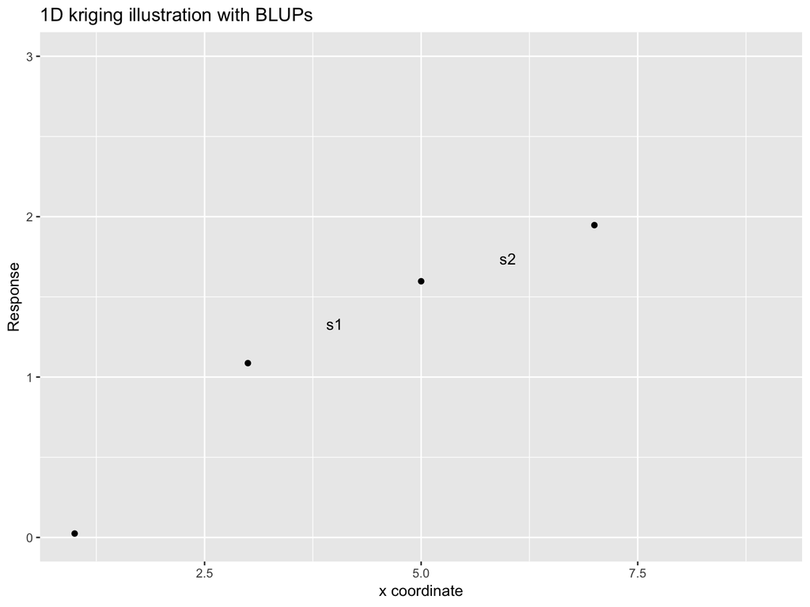

# Kriging with Gaussian Processes

## A Gaussian Process

- The BLUP does not contain a distributional assumptions, but rather comes from an optimization framework.
- Now assume that
  $$\boldsymbol{Y} = \mu \boldsymbol{1} + \boldsymbol{\epsilon}, \; \; \text{ where } \boldsymbol{\epsilon} \sim N(\boldsymbol{0}, \Sigma)$$
- With no nugget, let $\Sigma = \sigma^2 H(\phi)$, where $(H(\phi))_{ij} = \rho(\phi; d_{ij})$, where $d_{ij}$ is the distance between $\boldsymbol{s}_{i}$ and $\boldsymbol{s}_j$.
- A nugget can be included by modifying $\Sigma$ to be $\Sigma = \sigma^2 H(\phi) + \tau^2 I$

## Minimizing Mean-Square Prediction Error

- **Goal:** find $h(\boldsymbol{y})$ that minimizes
  $$E[(\boldsymbol{Y}(\boldsymbol{s_0}) - h(\boldsymbol{y}))^2 | \boldsymbol{y}]$$
- $$E[(\boldsymbol{Y}(\boldsymbol{s_0}) - h(\boldsymbol{y}))^2 | \boldsymbol{y}]= E[(\boldsymbol{Y}(\boldsymbol{s_0}) - h(\boldsymbol{y}) \pm E[(\boldsymbol{Y}(\boldsymbol{s_0}|\boldsymbol{y})])^2 | \boldsymbol{y}]$$
- $$=E \{(\boldsymbol{Y}(\boldsymbol{s_0}) - E[(\boldsymbol{Y}(\boldsymbol{s_0})|\boldsymbol{y}])^2|\boldsymbol{y} \} + \{ E[(\boldsymbol{Y}(\boldsymbol{s_0})|y] - h(\boldsymbol{y}) \}^2$$

## Minimizing Mean-Square Prediction Error: Part 2

- As $\{ E[(\boldsymbol{Y}(\boldsymbol{s_0})|y] - h(\boldsymbol{y}) \}^2 \geq 0$
- we have
  $$E[(\boldsymbol{Y}(\boldsymbol{s_0}) - h(\boldsymbol{y}))^2 | \boldsymbol{y}] \geq E \{(\boldsymbol{Y}(\boldsymbol{s_0}) - E[(\boldsymbol{Y}(\boldsymbol{s_0})|\boldsymbol{y}])^2|\boldsymbol{y} \}$$
- Hence to minimize $E[(\boldsymbol{Y}(\boldsymbol{s_0}) - h(\boldsymbol{y}))^2 | \boldsymbol{y}]$, we set …
- $h(\boldsymbol{y}) = E[(\boldsymbol{Y}(\boldsymbol{s_0})|\boldsymbol{y}]$
- Hence, $h(\boldsymbol{y})$ that minimizes the error is the conditional expectation of $\boldsymbol{Y}(\boldsymbol{s_0})$
- Note this is also the *posterior mean* of $\boldsymbol{Y}(\boldsymbol{s_0})$

## Multivariate Normal Theory

- For consider partioning a multivariate normal distribution into two parts
  $$\begin{pmatrix}
  \boldsymbol{Y_1}\\
  \boldsymbol{Y_2}
  \end{pmatrix} =
  N \left( \begin{pmatrix}
  \boldsymbol{\mu_1}\\
  \boldsymbol{\mu_2}
  \end{pmatrix}, \begin{pmatrix}
  \Omega_{11} \;\;\Omega_{12}\\
  \Omega_{21} \;\;\Omega_{22}\end{pmatrix}\right),$$
  where $\Omega_{12} = \Omega_{21}^T$

## Conditional Multivariate Normal Theory

- The conditional distribution, $p(\boldsymbol{Y_1}| \boldsymbol{Y_2})$ is normal with:
- $E[\boldsymbol{Y_1}| \boldsymbol{Y_2}] = \boldsymbol{\mu_1} + \Omega_{12} \Omega_{22}^{-1} (\boldsymbol{Y_2} - \mu_2)$
- $Var[\boldsymbol{Y_1}| \boldsymbol{Y_2}] = \Omega_{11} - \Omega_{12} \Omega_{22}^{-1} \Omega_{21}$
- Thus with $\boldsymbol{Y_1} = Y(\boldsymbol{s_0})$ and $\boldsymbol{Y_2} = \boldsymbol{y}$
  $$\Omega_{11} = \sigma^2 + \tau^2, \; \; \; \Omega_{12} = (\sigma^2 p(\phi;d_{01})), \dots, p(\phi;d_{0n})))$$
  $$\Omega_{22} = \sigma^2 H(\phi) + \tau^2 I$$

# Gaussian Process Exercise:

## Overview

- Similar to the previous exercise, we will simulate data from a 1D process and make predictions at unobserved locations - which is the interval [0,10].
- In this situation, please plot the mean of the distribution as well as some uncertainty metric.
- You do not need to estimate $\sigma^2$, $\tau^2$, and $\phi$ but can use the known values in the R code.

## Data Overview

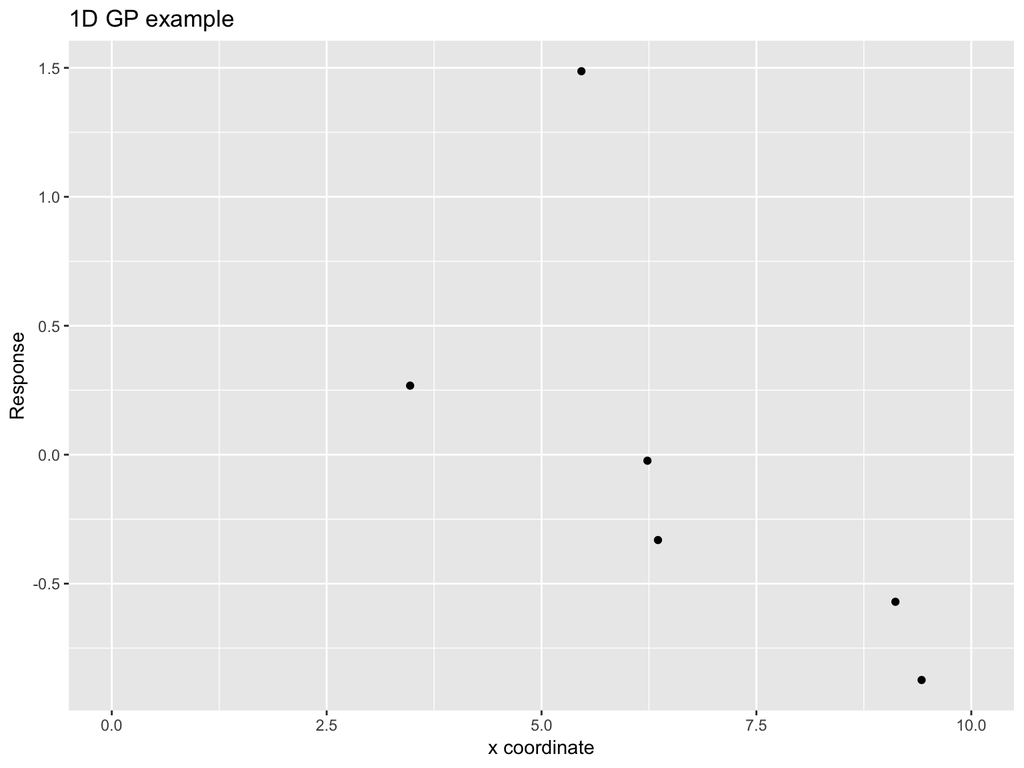

## Conditional Expectation

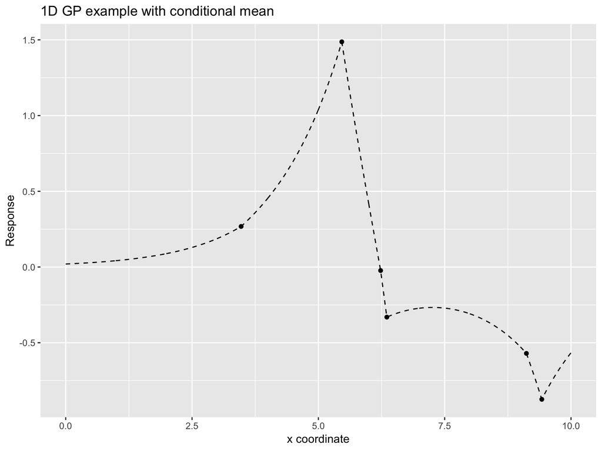

## Conditional Expectation and Intervals

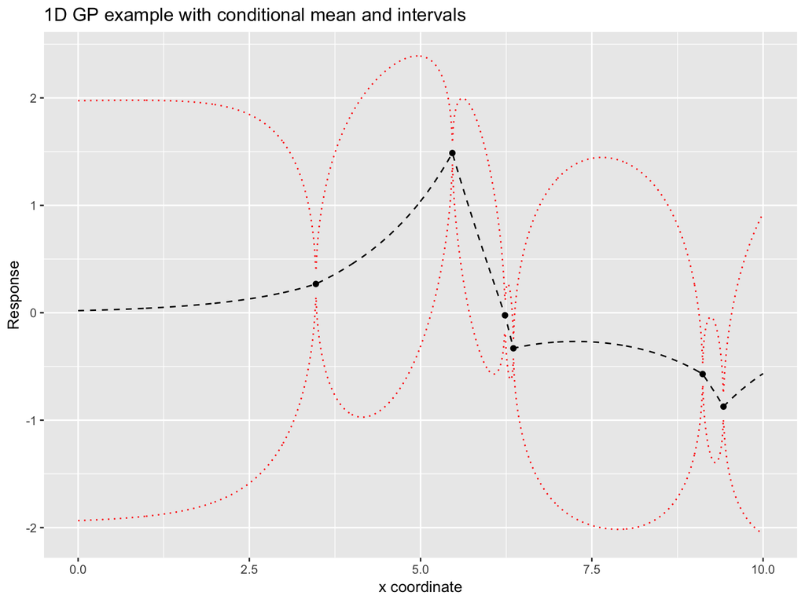

## Follow up Questions

- Consider the conditional expectation,
  $$E[\boldsymbol{Y_1}|
  \boldsymbol{Y_2}] = \boldsymbol{\mu_1} + \Omega_{12} \Omega_{22}^{-1} (\boldsymbol{Y_2} - \mu_2)$$
  How is this resultant expectation impacted by $\Omega_{12} \Omega_{22}^{-1}$? How is this resultant expectation impacted by $(\boldsymbol{Y_2} - \mu_2)$?
- Similarly, how does the conditional variance
  $$Var[\boldsymbol{Y_1}|
  \boldsymbol{Y_2}] = \Omega_{11} - \Omega_{12} \Omega_{22}^{-1} \Omega_{21}$$
  change as a function of $\Omega_{12} \Omega_{22}^{-1} \Omega_{21}$?
- If we add a nugget to the previous example, how do the predictions change?
- How does the scenario change if $\mu_1$ and $\mu_2$ are not zero, but rather say $\mu_1 = X_1 \beta$ and $\mu_2 = X_2 \beta$?

## 2D Kriging

Discuss how the spatial range could be extended to $\mathcal{R}^2$ rather than $\mathcal{R}^1$. What changes in this situation?

## Functions in R for 2D kriging

- The `krige` function in `gstat` contains a function for kriging ; however, this requires a known variogram.

```
## [using ordinary kriging]
```

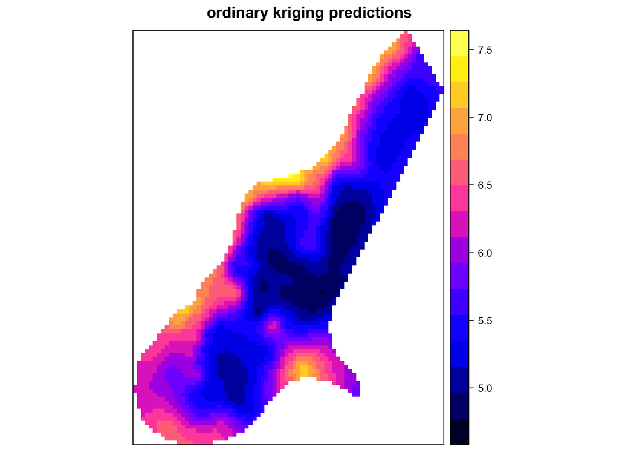

## Universal Kriging

- When covariate information is available for inclusion in the analysis, this is often referred to as *universal kriging*
- Now we have
  $$\boldsymbol{Y} = X \boldsymbol{\beta} + \boldsymbol{\epsilon}, \; \; \text{ where } \boldsymbol{\epsilon} \sim N(\boldsymbol{0}, \Sigma)$$
- The conditional distributions are very similar to what we have derived above, watch for HW question.
- In each case, kriging or universal kriging, it is still necessary to estimate the following parameters: $\sigma^2,$ $\tau^2$, $\phi$, and $\mu$ or $\beta$.
- This can be done with least-squares methods or in a Bayesian framework.

## About those other parameters

We still need

- to choose an appropriate covariance function (or semivariogram)
- and estimate parameters in that function